# Brief Introduction to caret

Stefano Galelli

02/01/2020

First, we prepare the working environment.

```r
rm(list=ls()) # Clear the environment
# setwd("...")  # Setup the working directory
```

# 1 Installing `caret`

We install it using the following command (which also accounts for dependencies):

```r
# install.packages("caret", dependencies = c("Depends", "Suggests"))
library(caret)
```

# 2 Data Preparation

## 2.1 The US Supreme Court dataset

Recall that our goal is to predict justice justice Stevens’ decision using six predictors. The output that takes a value of 1 if Stevens’ decision reverses the lower court decision and 0 if the judge affirms the lower court decision.

```r
# Load data
supreme <- read.csv("supreme.csv") # We have 623 observations and 20 variables
# str(supreme)      # Internal structure of the dataframe
# head(supreme)    # First part of the dataframe

# Prepare the output variable (justice Stevens' decision)
stevens <- subset(supreme[,c("docket","term","stevdir","petit","respon","circuit","unconst","lctdir","issue","result")],supreme$stevdir!=9)
stevens$rev <- as.integer((stevens$lctdir=="conser" & stevens$stevdir==0) | (stevens$lctdir=="liberal" & stevens$stevdir==1))
```

## 2.2 Splitting the dataset

To split the data into two groups (for training and testing), we use the function `createDataPartition`

```r
# set seed for random sampling
set.seed(123)
inTrain <- createDataPartition(
  y = stevens$rev, # output variable
  p = 0.70, # percentage of data in the training set
  list = FALSE # whether to return the results of the random sampling
)
# str(inTrain)
```

The output is a set of integers for the rows of `rev` that belong to the training set, so we just need to use the indices when creating the train and test sets.

```r
train <- stevens[inTrain, ];  # training dataset
test  <- stevens[-inTrain, ]; # testing dataset
```

# 3 Training a model

## 3.1 Basics

To build a model, we use the `train` function, which is the core of the `caret` package. Here, we will use it with a very simple syntax (much more can be found at https://topepo.github.io/caret/model-training-and-tuning.html).

```r
FitCART <- train(
  as.factor(rev)~petit+respon+circuit+lctdir+issue+unconst,
  data = train,
  method = "rpart"
)
```

The variable `FitCART` contains all information about the CART we trained. Here, we look at the model performance. Note that across each data set, the performance of held-out samples is calculated and the mean and standard deviation is summarized for each combination. The combination with the optimal resampling statistic is chosen as the final model and the entire training set is used to fit a final model.

```r
FitCART$results
```

```
##           cp  Accuracy     Kappa AccuracySD    KappaSD
## 1 0.00331675 0.6126645 0.2177179 0.03783128 0.07578703
## 2 0.01658375 0.6283376 0.2489522 0.03359920 0.07096052
## 3 0.23880597 0.5799934 0.1313310 0.06219330 0.14460618
```

## 3.2 Changing the sampling method

```r
train_control <- trainControl(method="cv", number=10)
FitCART <- train(
  as.factor(rev)~petit+respon+circuit+lctdir+issue+unconst,
  data = train,
  method = "rpart",
  trControl = train_control
)
```

Because we used a different method for testing, the model performance is slightly different

```r
FitCART$results
```

```
##           cp  Accuracy      Kappa AccuracySD    KappaSD
## 1 0.00331675 0.5886364 0.16986357 0.13259798 0.26533314
## 2 0.01658375 0.6467230 0.29251693 0.08811635 0.17205516
## 3 0.23880597 0.5554440 0.07366387 0.03881927 0.09970763
```

## 3.3 Exploring the role of the tuning parameter(s)

With the option `tuneLength`, we can play with the number of levels for each tuning parameter. Note that in the case of CART, we can work only with the parameter `CP`.

```r
train_control <- trainControl(method="cv", number=10)
FitCART <- train(
  as.factor(rev)~petit+respon+circuit+lctdir+issue+unconst,
  data = train,
  method = "rpart",
  tuneLength = 10,
  trControl = train_control
)
```

In the table below we can see the performance (on a 10-fold cross-validation) for 10 different values of `CP`.

```r
FitCART$results
```

```
##            cp  Accuracy      Kappa AccuracySD   KappaSD
## 1  0.00000000 0.6080338 0.21221147 0.06987467 0.1367987
## 2  0.02653400 0.6404334 0.27989241 0.07338799 0.1445603
## 3  0.05306799 0.6473573 0.29474699 0.06981361 0.1358804
## 4  0.07960199 0.6473573 0.29474699 0.06981361 0.1358804
## 5  0.10613599 0.6473573 0.29474699 0.06981361 0.1358804
## 6  0.13266998 0.6473573 0.29474699 0.06981361 0.1358804
## 7  0.15920398 0.6473573 0.29474699 0.06981361 0.1358804
## 8  0.18573798 0.6473573 0.29474699 0.06981361 0.1358804
## 9  0.21227197 0.6241015 0.24148612 0.06384628 0.1366674
## 10 0.23880597 0.5575053 0.06878173 0.03483992 0.1032620
```

## 3.4 Making predictions on the test dataset

To make predictions on the testing dataset, we use the function `predict.train`

```r
predictCART <- predict(FitCART, newdata = test)
```

The function `confusionMatrix` will provide us many statistics we need

```r
confusionMatrix(data = predictCART, as.factor(test$rev))
```

```
## Confusion Matrix and Statistics
##
##           Reference
## Prediction  0  1
##          0 54 32
##          1 23 76
##
##                Accuracy : 0.7027
##                  95% CI : (0.6312, 0.7675)
##     No Information Rate : 0.5838
##     P-Value [Acc > NIR] : 0.0005534
##
##                   Kappa : 0.3983
##
##  Mcnemar's Test P-Value : 0.2807127
##
##             Sensitivity : 0.7013
##             Specificity : 0.7037
##          Pos Pred Value : 0.6279
##          Neg Pred Value : 0.7677
##              Prevalence : 0.4162
##          Detection Rate : 0.2919
##    Detection Prevalence : 0.4649
##       Balanced Accuracy : 0.7025
##
##        'Positive' Class : 0
##
```

# 4 Training and testing a different model

To fit an another model to the data, `train` can be invoked with minimal changes. Here, we train a Logistic regression model using the same sampling method applied to the CART. (The model has no tuning parameter.)

```r
FitLR <- train(
  as.factor(rev)~petit+respon+circuit+lctdir+issue+unconst,
  data = train,
  method = "glm",
  trControl = train_control
)
```

Model performance

```r
FitLR$results
```

```
##   parameter  Accuracy     Kappa AccuracySD   KappaSD
## 1      none 0.6543869 0.3015152 0.06427686 0.1320558
```

Model performance on the test dataset

```r
predictLR <- predict(FitLR, newdata = test)
confusionMatrix(data = predictLR, as.factor(test$rev))
```

```
## Confusion Matrix and Statistics
##
##           Reference
## Prediction  0  1
##          0 49 31
##          1 28 77
##
##                Accuracy : 0.6811
##                  95% CI : (0.6087, 0.7475)
##     No Information Rate : 0.5838
##     P-Value [Acc > NIR] : 0.004114
##
##                   Kappa : 0.3474
##
##  Mcnemar's Test P-Value : 0.794572
##
##             Sensitivity : 0.6364
##             Specificity : 0.7130
##          Pos Pred Value : 0.6125
##          Neg Pred Value : 0.7333
##              Prevalence : 0.4162
##          Detection Rate : 0.2649
##    Detection Prevalence : 0.4324
##       Balanced Accuracy : 0.6747
##
##        'Positive' Class : 0
##
```

# 5 Comparing models

```r
resamps <- resamples(list(CART = FitCART, LR = FitLR))
summary(resamps)
```

```
##
## Call:
## summary.resamples(object = resamps)
##
## Models: CART, LR
## Number of resamples: 10
##
## Accuracy
##           Min.   1st Qu.    Median      Mean   3rd Qu.      Max. NA's
## CART 0.5348837 0.6125793 0.6551268 0.6473573 0.6761364 0.7674419    0
## LR   0.5813953 0.6104651 0.6437632 0.6543869 0.6705867 0.7906977    0
##
## Kappa
##           Min.   1st Qu.    Median      Mean   3rd Qu.      Max. NA's
## CART 0.0712743 0.2291511 0.3088035 0.2947470 0.3422259 0.5326087    0
## LR   0.1475771 0.2124437 0.2816042 0.3015152 0.3334234 0.5807151    0
```

We can also grphically compare the models

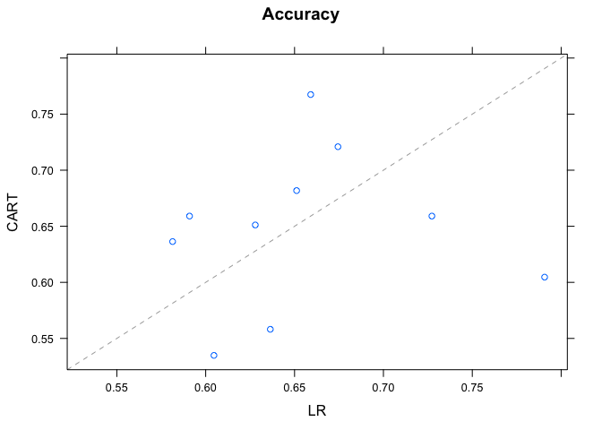

```r
xyplot(resamps)
```